# Risk Factor Analysis

## Outcome Variable

**Outcome Variable:** ever_stunted

## Predictor Variables

**Intervention Variable:** vagbrth

**Adjustment Set:**

- arm
- W_mage
- meducyrs
- feducyrs
- W_mhtcm
- W_mwtkg
- W_mbmi
- single
- brthmon
- W_parity
- delta_W_mage
- delta_meducyrs
- delta_feducyrs
- delta_W_mhtcm
- delta_W_mwtkg
- delta_W_mbmi
- delta_single
- delta_brthmon
- delta_W_parity

## Stratifying Variables

The analysis was stratified on these variable(s):

- agecat
- studyid
- country

## Data Summary

| agecat | studyid | country | vagbrth | ever_stunted | n_cell | n |
| --- | --- | --- | --- | --- | --- | --- |
| 0-24 months (no birth st.) | ki1000108-CMC-V-BCS-2002 | INDIA | 0 | 0 | 3 | 296 |
| 0-24 months (no birth st.) | ki1000108-CMC-V-BCS-2002 | INDIA | 0 | 1 | 17 | 296 |
| 0-24 months (no birth st.) | ki1000108-CMC-V-BCS-2002 | INDIA | 1 | 0 | 25 | 296 |
| 0-24 months (no birth st.) | ki1000108-CMC-V-BCS-2002 | INDIA | 1 | 1 | 251 | 296 |
| 0-24 months (no birth st.) | ki1000108-IRC | INDIA | 0 | 0 | 24 | 360 |
| 0-24 months (no birth st.) | ki1000108-IRC | INDIA | 0 | 1 | 35 | 360 |
| 0-24 months (no birth st.) | ki1000108-IRC | INDIA | 1 | 0 | 123 | 360 |
| 0-24 months (no birth st.) | ki1000108-IRC | INDIA | 1 | 1 | 178 | 360 |
| 0-24 months (no birth st.) | ki1017093b-PROVIDE | BANGLADESH | 0 | 0 | 97 | 633 |
| 0-24 months (no birth st.) | ki1017093b-PROVIDE | BANGLADESH | 0 | 1 | 46 | 633 |
| 0-24 months (no birth st.) | ki1017093b-PROVIDE | BANGLADESH | 1 | 0 | 298 | 633 |
| 0-24 months (no birth st.) | ki1017093b-PROVIDE | BANGLADESH | 1 | 1 | 192 | 633 |
| 0-24 months (no birth st.) | ki1017093c-NIH-Crypto | BANGLADESH | 0 | 0 | 117 | 432 |
| 0-24 months (no birth st.) | ki1017093c-NIH-Crypto | BANGLADESH | 0 | 1 | 58 | 432 |
| 0-24 months (no birth st.) | ki1017093c-NIH-Crypto | BANGLADESH | 1 | 0 | 136 | 432 |
| 0-24 months (no birth st.) | ki1017093c-NIH-Crypto | BANGLADESH | 1 | 1 | 121 | 432 |
| 0-24 months (no birth st.) | ki1066203-TanzaniaChild2 | TANZANIA, UNITED REPUBLIC OF | 0 | 0 | 145 | 2207 |
| 0-24 months (no birth st.) | ki1066203-TanzaniaChild2 | TANZANIA, UNITED REPUBLIC OF | 0 | 1 | 47 | 2207 |
| 0-24 months (no birth st.) | ki1066203-TanzaniaChild2 | TANZANIA, UNITED REPUBLIC OF | 1 | 0 | 1402 | 2207 |
| 0-24 months (no birth st.) | ki1066203-TanzaniaChild2 | TANZANIA, UNITED REPUBLIC OF | 1 | 1 | 613 | 2207 |
| 0-24 months (no birth st.) | ki1119695-PROBIT | BELARUS | 0 | 0 | 1640 | 16742 |
| 0-24 months (no birth st.) | ki1119695-PROBIT | BELARUS | 0 | 1 | 294 | 16742 |
| 0-24 months (no birth st.) | ki1119695-PROBIT | BELARUS | 1 | 0 | 12427 | 16742 |
| 0-24 months (no birth st.) | ki1119695-PROBIT | BELARUS | 1 | 1 | 2381 | 16742 |
| 0-24 months (no birth st.) | ki1126311-ZVITAMBO | ZIMBABWE | 0 | 0 | 707 | 12502 |
| 0-24 months (no birth st.) | ki1126311-ZVITAMBO | ZIMBABWE | 0 | 1 | 380 | 12502 |
| 0-24 months (no birth st.) | ki1126311-ZVITAMBO | ZIMBABWE | 1 | 0 | 7435 | 12502 |
| 0-24 months (no birth st.) | ki1126311-ZVITAMBO | ZIMBABWE | 1 | 1 | 3980 | 12502 |
| 0-24 months (no birth st.) | kiGH5241-JiVitA-3 | BANGLADESH | 0 | 0 | 974 | 18291 |
| 0-24 months (no birth st.) | kiGH5241-JiVitA-3 | BANGLADESH | 0 | 1 | 196 | 18291 |

[output cut: 78 more lines]

The following strata were considered:

- agecat: 0-24 months (no birth st.), studyid: ki1000108-CMC-V-BCS-2002, country: INDIA
- agecat: 0-24 months (no birth st.), studyid: ki1000108-IRC, country: INDIA
- agecat: 0-24 months (no birth st.), studyid: ki1017093b-PROVIDE, country: BANGLADESH
- agecat: 0-24 months (no birth st.), studyid: ki1017093c-NIH-Crypto, country: BANGLADESH
- agecat: 0-24 months (no birth st.), studyid: ki1066203-TanzaniaChild2, country: TANZANIA, UNITED REPUBLIC OF
- agecat: 0-24 months (no birth st.), studyid: ki1119695-PROBIT, country: BELARUS
- agecat: 0-24 months (no birth st.), studyid: ki1126311-ZVITAMBO, country: ZIMBABWE
- agecat: 0-24 months (no birth st.), studyid: kiGH5241-JiVitA-3, country: BANGLADESH
- agecat: 0-24 months (no birth st.), studyid: kiGH5241-JiVitA-4, country: BANGLADESH
- agecat: 0-6 months (no birth st.), studyid: ki1000108-CMC-V-BCS-2002, country: INDIA
- agecat: 0-6 months (no birth st.), studyid: ki1000108-IRC, country: INDIA
- agecat: 0-6 months (no birth st.), studyid: ki1017093b-PROVIDE, country: BANGLADESH
- agecat: 0-6 months (no birth st.), studyid: ki1017093c-NIH-Crypto, country: BANGLADESH
- agecat: 0-6 months (no birth st.), studyid: ki1066203-TanzaniaChild2, country: TANZANIA, UNITED REPUBLIC OF
- agecat: 0-6 months (no birth st.), studyid: ki1119695-PROBIT, country: BELARUS
- agecat: 0-6 months (no birth st.), studyid: ki1126311-ZVITAMBO, country: ZIMBABWE
- agecat: 0-6 months (no birth st.), studyid: kiGH5241-JiVitA-3, country: BANGLADESH
- agecat: 0-6 months (no birth st.), studyid: kiGH5241-JiVitA-4, country: BANGLADESH
- agecat: 6-24 months, studyid: ki1000108-CMC-V-BCS-2002, country: INDIA
- agecat: 6-24 months, studyid: ki1000108-IRC, country: INDIA
- agecat: 6-24 months, studyid: ki1017093b-PROVIDE, country: BANGLADESH
- agecat: 6-24 months, studyid: ki1017093c-NIH-Crypto, country: BANGLADESH
- agecat: 6-24 months, studyid: ki1066203-TanzaniaChild2, country: TANZANIA, UNITED REPUBLIC OF
- agecat: 6-24 months, studyid: ki1119695-PROBIT, country: BELARUS
- agecat: 6-24 months, studyid: ki1126311-ZVITAMBO, country: ZIMBABWE
- agecat: 6-24 months, studyid: kiGH5241-JiVitA-3, country: BANGLADESH
- agecat: 6-24 months, studyid: kiGH5241-JiVitA-4, country: BANGLADESH

### Dropped Strata

Some strata were dropped due to rare outcomes:

- agecat: 0-24 months (no birth st.), studyid: ki1000108-CMC-V-BCS-2002, country: INDIA
- agecat: 6-24 months, studyid: ki1000108-CMC-V-BCS-2002, country: INDIA

## Methods Detail

We’re interested in the causal parameters $E[Y_a]$ for all values of $a \in \mathcal{A}$. These parameters represent the mean outcome if, possibly contrary to fact, we intervened to set all units to have $A=a$. Under the randomization and positivity assumptions, these are identified by the statistical parameters $\psi_a=E_W[E_{Y|A,W}(Y|A=a,W)]$. In addition, we’re interested in the mean of $Y$, $E[Y]$ under no intervention (the observed mean). We will estimate these parameters by using SuperLearner to fit the relevant likelihood factors – $E_{Y|A,W}(Y|A=a,W)$ and $p(A=a|W)$, and then updating our likelihood fit using a joint TMLE.

For unadjusted analyses ($W=\{\}$), initial likelihoods were estimated using Lrnr_glm to estimate the simple $E(Y|A)$ and Lrnr_mean to estimate $p(A)$. For adjusted analyses, a small library containing Lrnr_glmnet, Lrnr_xgboost, and Lrnr_mean was used.

Having estimated these parameters, we will then use the delta method to estimate relative risks and attributable risks relative to a prespecified baseline level of $A$.

# Results Detail

## Results Plots

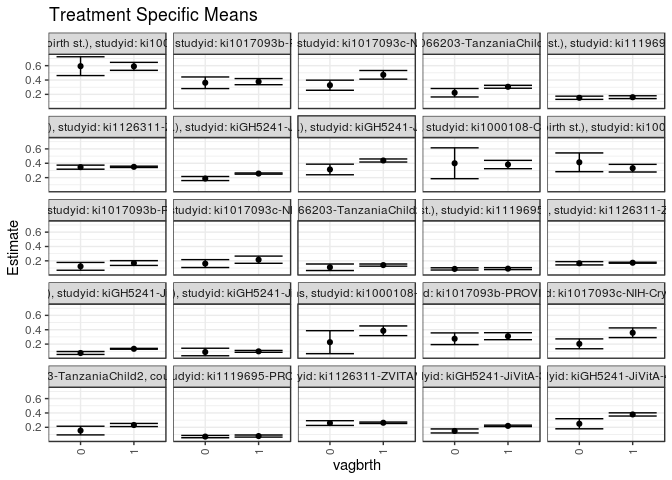

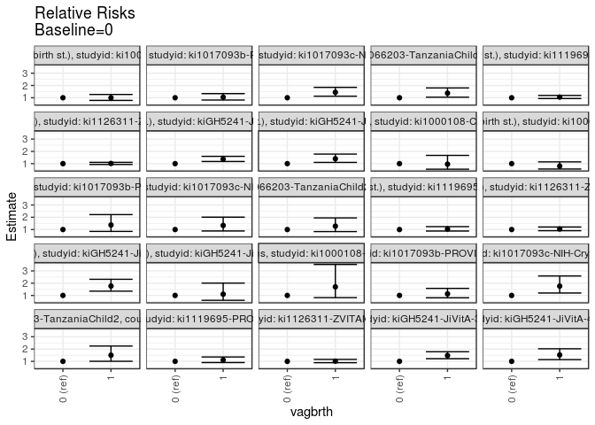

[figure not shown]

[figure not shown]

## Results Table

### Parameter: TSM

| agecat | studyid | country | intervention_level | baseline_level | estimate | ci_lower | ci_upper |
| --- | --- | --- | --- | --- | --- | --- | --- |
| 0-24 months (no birth st.) | ki1000108-IRC | INDIA | 0 | NA | 0.5931904 | 0.4623237 | 0.7240571 |
| 0-24 months (no birth st.) | ki1000108-IRC | INDIA | 1 | NA | 0.5905295 | 0.5348917 | 0.6461673 |
| 0-24 months (no birth st.) | ki1017093b-PROVIDE | BANGLADESH | 0 | NA | 0.3620945 | 0.2812279 | 0.4429611 |
| 0-24 months (no birth st.) | ki1017093b-PROVIDE | BANGLADESH | 1 | NA | 0.3776496 | 0.3350230 | 0.4202762 |
| 0-24 months (no birth st.) | ki1017093c-NIH-Crypto | BANGLADESH | 0 | NA | 0.3276780 | 0.2574505 | 0.3979055 |
| 0-24 months (no birth st.) | ki1017093c-NIH-Crypto | BANGLADESH | 1 | NA | 0.4724346 | 0.4119361 | 0.5329331 |
| 0-24 months (no birth st.) | ki1066203-TanzaniaChild2 | TANZANIA, UNITED REPUBLIC OF | 0 | NA | 0.2230690 | 0.1639949 | 0.2821430 |
| 0-24 months (no birth st.) | ki1066203-TanzaniaChild2 | TANZANIA, UNITED REPUBLIC OF | 1 | NA | 0.3058219 | 0.2857224 | 0.3259213 |
| 0-24 months (no birth st.) | ki1119695-PROBIT | BELARUS | 0 | NA | 0.1525834 | 0.1302791 | 0.1748878 |
| 0-24 months (no birth st.) | ki1119695-PROBIT | BELARUS | 1 | NA | 0.1609129 | 0.1413717 | 0.1804541 |
| 0-24 months (no birth st.) | ki1126311-ZVITAMBO | ZIMBABWE | 0 | NA | 0.3455071 | 0.3171426 | 0.3738716 |
| 0-24 months (no birth st.) | ki1126311-ZVITAMBO | ZIMBABWE | 1 | NA | 0.3502106 | 0.3414832 | 0.3589379 |
| 0-24 months (no birth st.) | kiGH5241-JiVitA-3 | BANGLADESH | 0 | NA | 0.1872168 | 0.1588767 | 0.2155568 |
| 0-24 months (no birth st.) | kiGH5241-JiVitA-3 | BANGLADESH | 1 | NA | 0.2564088 | 0.2484710 | 0.2643465 |
| 0-24 months (no birth st.) | kiGH5241-JiVitA-4 | BANGLADESH | 0 | NA | 0.3134891 | 0.2395677 | 0.3874105 |
| 0-24 months (no birth st.) | kiGH5241-JiVitA-4 | BANGLADESH | 1 | NA | 0.4384273 | 0.4169924 | 0.4598622 |
| 0-6 months (no birth st.) | ki1000108-CMC-V-BCS-2002 | INDIA | 0 | NA | 0.4000000 | 0.1849281 | 0.6150719 |
| 0-6 months (no birth st.) | ki1000108-CMC-V-BCS-2002 | INDIA | 1 | NA | 0.3823529 | 0.3245019 | 0.4402040 |
| 0-6 months (no birth st.) | ki1000108-IRC | INDIA | 0 | NA | 0.4134184 | 0.2829544 | 0.5438823 |
| 0-6 months (no birth st.) | ki1000108-IRC | INDIA | 1 | NA | 0.3313948 | 0.2781401 | 0.3846496 |
| 0-6 months (no birth st.) | ki1017093b-PROVIDE | BANGLADESH | 0 | NA | 0.1234053 | 0.0691683 | 0.1776423 |
| 0-6 months (no birth st.) | ki1017093b-PROVIDE | BANGLADESH | 1 | NA | 0.1691424 | 0.1358260 | 0.2024588 |
| 0-6 months (no birth st.) | ki1017093c-NIH-Crypto | BANGLADESH | 0 | NA | 0.1619441 | 0.1066951 | 0.2171932 |
| 0-6 months (no birth st.) | ki1017093c-NIH-Crypto | BANGLADESH | 1 | NA | 0.2157853 | 0.1655342 | 0.2660364 |
| 0-6 months (no birth st.) | ki1066203-TanzaniaChild2 | TANZANIA, UNITED REPUBLIC OF | 0 | NA | 0.1106283 | 0.0650994 | 0.1561571 |
| 0-6 months (no birth st.) | ki1066203-TanzaniaChild2 | TANZANIA, UNITED REPUBLIC OF | 1 | NA | 0.1410145 | 0.1258443 | 0.1561847 |
| 0-6 months (no birth st.) | ki1119695-PROBIT | BELARUS | 0 | NA | 0.0875951 | 0.0721515 | 0.1030386 |
| 0-6 months (no birth st.) | ki1119695-PROBIT | BELARUS | 1 | NA | 0.0912746 | 0.0775359 | 0.1050133 |
| 0-6 months (no birth st.) | ki1126311-ZVITAMBO | ZIMBABWE | 0 | NA | 0.1660149 | 0.1431158 | 0.1889140 |
| 0-6 months (no birth st.) | ki1126311-ZVITAMBO | ZIMBABWE | 1 | NA | 0.1734658 | 0.1665185 | 0.1804131 |
| 0-6 months (no birth st.) | kiGH5241-JiVitA-3 | BANGLADESH | 0 | NA | 0.0759292 | 0.0555519 | 0.0963065 |
| 0-6 months (no birth st.) | kiGH5241-JiVitA-3 | BANGLADESH | 1 | NA | 0.1341876 | 0.1283433 | 0.1400319 |
| 0-6 months (no birth st.) | kiGH5241-JiVitA-4 | BANGLADESH | 0 | NA | 0.0895517 | 0.0371501 | 0.1419534 |
| 0-6 months (no birth st.) | kiGH5241-JiVitA-4 | BANGLADESH | 1 | NA | 0.0986522 | 0.0856717 | 0.1116327 |
| 6-24 months | ki1000108-IRC | INDIA | 0 | NA | 0.2265647 | 0.0665248 | 0.3866047 |
| 6-24 months | ki1000108-IRC | INDIA | 1 | NA | 0.3851957 | 0.3175102 | 0.4528813 |
| 6-24 months | ki1017093b-PROVIDE | BANGLADESH | 0 | NA | 0.2744141 | 0.1928415 | 0.3559866 |
| 6-24 months | ki1017093b-PROVIDE | BANGLADESH | 1 | NA | 0.3099182 | 0.2612085 | 0.3586279 |
| 6-24 months | ki1017093c-NIH-Crypto | BANGLADESH | 0 | NA | 0.2032837 | 0.1345103 | 0.2720570 |
| 6-24 months | ki1017093c-NIH-Crypto | BANGLADESH | 1 | NA | 0.3578605 | 0.2902509 | 0.4254702 |
| 6-24 months | ki1066203-TanzaniaChild2 | TANZANIA, UNITED REPUBLIC OF | 0 | NA | 0.1544346 | 0.0939930 | 0.2148763 |
| 6-24 months | ki1066203-TanzaniaChild2 | TANZANIA, UNITED REPUBLIC OF | 1 | NA | 0.2320280 | 0.2101868 | 0.2538692 |
| 6-24 months | ki1119695-PROBIT | BELARUS | 0 | NA | 0.0706852 | 0.0547010 | 0.0866693 |
| 6-24 months | ki1119695-PROBIT | BELARUS | 1 | NA | 0.0781787 | 0.0635369 | 0.0928205 |
| 6-24 months | ki1126311-ZVITAMBO | ZIMBABWE | 0 | NA | 0.2591029 | 0.2263460 | 0.2918599 |
| 6-24 months | ki1126311-ZVITAMBO | ZIMBABWE | 1 | NA | 0.2633458 | 0.2535018 | 0.2731898 |
| 6-24 months | kiGH5241-JiVitA-3 | BANGLADESH | 0 | NA | 0.1493459 | 0.1212586 | 0.1774331 |
| 6-24 months | kiGH5241-JiVitA-3 | BANGLADESH | 1 | NA | 0.2199922 | 0.2102976 | 0.2296868 |
| 6-24 months | kiGH5241-JiVitA-4 | BANGLADESH | 0 | NA | 0.2494837 | 0.1794111 | 0.3195564 |
| 6-24 months | kiGH5241-JiVitA-4 | BANGLADESH | 1 | NA | 0.3793534 | 0.3573286 | 0.4013783 |

### Parameter: E(Y)

| agecat | studyid | country | intervention_level | baseline_level | estimate | ci_lower | ci_upper |
| --- | --- | --- | --- | --- | --- | --- | --- |
| 0-24 months (no birth st.) | ki1000108-IRC | INDIA | NA | NA | 0.5916667 | 0.5408218 | 0.6425115 |
| 0-24 months (no birth st.) | ki1017093b-PROVIDE | BANGLADESH | NA | NA | 0.3759874 | 0.3382238 | 0.4137509 |
| 0-24 months (no birth st.) | ki1017093c-NIH-Crypto | BANGLADESH | NA | NA | 0.4143519 | 0.3678455 | 0.4608582 |
| 0-24 months (no birth st.) | ki1066203-TanzaniaChild2 | TANZANIA, UNITED REPUBLIC OF | NA | NA | 0.2990485 | 0.2799429 | 0.3181541 |
| 0-24 months (no birth st.) | ki1119695-PROBIT | BELARUS | NA | NA | 0.1597778 | 0.1408215 | 0.1787342 |
| 0-24 months (no birth st.) | ki1126311-ZVITAMBO | ZIMBABWE | NA | NA | 0.3487442 | 0.3403900 | 0.3570984 |
| 0-24 months (no birth st.) | kiGH5241-JiVitA-3 | BANGLADESH | NA | NA | 0.2522552 | 0.2445070 | 0.2600034 |
| 0-24 months (no birth st.) | kiGH5241-JiVitA-4 | BANGLADESH | NA | NA | 0.4270574 | 0.4065290 | 0.4475857 |
| 0-6 months (no birth st.) | ki1000108-CMC-V-BCS-2002 | INDIA | NA | NA | 0.3835616 | 0.3276935 | 0.4394298 |
| 0-6 months (no birth st.) | ki1000108-IRC | INDIA | NA | NA | 0.3444444 | 0.2952897 | 0.3935992 |
| 0-6 months (no birth st.) | ki1017093b-PROVIDE | BANGLADESH | NA | NA | 0.1595577 | 0.1310079 | 0.1881074 |
| 0-6 months (no birth st.) | ki1017093c-NIH-Crypto | BANGLADESH | NA | NA | 0.1944444 | 0.1570803 | 0.2318086 |
| 0-6 months (no birth st.) | ki1066203-TanzaniaChild2 | TANZANIA, UNITED REPUBLIC OF | NA | NA | 0.1381966 | 0.1237955 | 0.1525978 |
| 0-6 months (no birth st.) | ki1119695-PROBIT | BELARUS | NA | NA | 0.0912784 | 0.0781588 | 0.1043979 |
| 0-6 months (no birth st.) | ki1126311-ZVITAMBO | ZIMBABWE | NA | NA | 0.1721902 | 0.1655693 | 0.1788111 |
| 0-6 months (no birth st.) | kiGH5241-JiVitA-3 | BANGLADESH | NA | NA | 0.1301138 | 0.1245115 | 0.1357160 |
| 0-6 months (no birth st.) | kiGH5241-JiVitA-4 | BANGLADESH | NA | NA | 0.0978125 | 0.0850264 | 0.1105986 |
| 6-24 months | ki1000108-IRC | INDIA | NA | NA | 0.3771186 | 0.3151523 | 0.4390850 |
| 6-24 months | ki1017093b-PROVIDE | BANGLADESH | NA | NA | 0.3004386 | 0.2583143 | 0.3425629 |
| 6-24 months | ki1017093c-NIH-Crypto | BANGLADESH | NA | NA | 0.2923077 | 0.2427834 | 0.3418319 |
| 6-24 months | ki1066203-TanzaniaChild2 | TANZANIA, UNITED REPUBLIC OF | NA | NA | 0.2243995 | 0.2038353 | 0.2449637 |
| 6-24 months | ki1119695-PROBIT | BELARUS | NA | NA | 0.0768510 | 0.0628857 | 0.0908164 |
| 6-24 months | ki1126311-ZVITAMBO | ZIMBABWE | NA | NA | 0.2627521 | 0.2533561 | 0.2721480 |
| 6-24 months | kiGH5241-JiVitA-3 | BANGLADESH | NA | NA | 0.2156694 | 0.2063399 | 0.2249988 |
| 6-24 months | kiGH5241-JiVitA-4 | BANGLADESH | NA | NA | 0.3674386 | 0.3465522 | 0.3883251 |

### Parameter: RR

| agecat | studyid | country | intervention_level | baseline_level | estimate | ci_lower | ci_upper |
| --- | --- | --- | --- | --- | --- | --- | --- |
| 0-24 months (no birth st.) | ki1000108-IRC | INDIA | 0 | 0 | 1.0000000 | 1.0000000 | 1.000000 |
| 0-24 months (no birth st.) | ki1000108-IRC | INDIA | 1 | 0 | 0.9955143 | 0.7833507 | 1.265141 |
| 0-24 months (no birth st.) | ki1017093b-PROVIDE | BANGLADESH | 0 | 0 | 1.0000000 | 1.0000000 | 1.000000 |
| 0-24 months (no birth st.) | ki1017093b-PROVIDE | BANGLADESH | 1 | 0 | 1.0429587 | 0.8137446 | 1.336737 |
| 0-24 months (no birth st.) | ki1017093c-NIH-Crypto | BANGLADESH | 0 | 0 | 1.0000000 | 1.0000000 | 1.000000 |
| 0-24 months (no birth st.) | ki1017093c-NIH-Crypto | BANGLADESH | 1 | 0 | 1.4417648 | 1.1256908 | 1.846587 |
| 0-24 months (no birth st.) | ki1066203-TanzaniaChild2 | TANZANIA, UNITED REPUBLIC OF | 0 | 0 | 1.0000000 | 1.0000000 | 1.000000 |
| 0-24 months (no birth st.) | ki1066203-TanzaniaChild2 | TANZANIA, UNITED REPUBLIC OF | 1 | 0 | 1.3709746 | 1.0445615 | 1.799388 |
| 0-24 months (no birth st.) | ki1119695-PROBIT | BELARUS | 0 | 0 | 1.0000000 | 1.0000000 | 1.000000 |
| 0-24 months (no birth st.) | ki1119695-PROBIT | BELARUS | 1 | 0 | 1.0545896 | 0.9343778 | 1.190267 |
| 0-24 months (no birth st.) | ki1126311-ZVITAMBO | ZIMBABWE | 0 | 0 | 1.0000000 | 1.0000000 | 1.000000 |
| 0-24 months (no birth st.) | ki1126311-ZVITAMBO | ZIMBABWE | 1 | 0 | 1.0136132 | 0.9306551 | 1.103966 |
| 0-24 months (no birth st.) | kiGH5241-JiVitA-3 | BANGLADESH | 0 | 0 | 1.0000000 | 1.0000000 | 1.000000 |
| 0-24 months (no birth st.) | kiGH5241-JiVitA-3 | BANGLADESH | 1 | 0 | 1.3695821 | 1.1750412 | 1.596331 |
| 0-24 months (no birth st.) | kiGH5241-JiVitA-4 | BANGLADESH | 0 | 0 | 1.0000000 | 1.0000000 | 1.000000 |
| 0-24 months (no birth st.) | kiGH5241-JiVitA-4 | BANGLADESH | 1 | 0 | 1.3985408 | 1.0992370 | 1.779340 |
| 0-6 months (no birth st.) | ki1000108-CMC-V-BCS-2002 | INDIA | 0 | 0 | 1.0000000 | 1.0000000 | 1.000000 |
| 0-6 months (no birth st.) | ki1000108-CMC-V-BCS-2002 | INDIA | 1 | 0 | 0.9558824 | 0.5467942 | 1.671033 |
| 0-6 months (no birth st.) | ki1000108-IRC | INDIA | 0 | 0 | 1.0000000 | 1.0000000 | 1.000000 |
| 0-6 months (no birth st.) | ki1000108-IRC | INDIA | 1 | 0 | 0.8015968 | 0.5623674 | 1.142594 |
| 0-6 months (no birth st.) | ki1017093b-PROVIDE | BANGLADESH | 0 | 0 | 1.0000000 | 1.0000000 | 1.000000 |
| 0-6 months (no birth st.) | ki1017093b-PROVIDE | BANGLADESH | 1 | 0 | 1.3706251 | 0.8470639 | 2.217794 |
| 0-6 months (no birth st.) | ki1017093c-NIH-Crypto | BANGLADESH | 0 | 0 | 1.0000000 | 1.0000000 | 1.000000 |
| 0-6 months (no birth st.) | ki1017093c-NIH-Crypto | BANGLADESH | 1 | 0 | 1.3324674 | 0.8842731 | 2.007829 |
| 0-6 months (no birth st.) | ki1066203-TanzaniaChild2 | TANZANIA, UNITED REPUBLIC OF | 0 | 0 | 1.0000000 | 1.0000000 | 1.000000 |
| 0-6 months (no birth st.) | ki1066203-TanzaniaChild2 | TANZANIA, UNITED REPUBLIC OF | 1 | 0 | 1.2746696 | 0.8337527 | 1.948758 |
| 0-6 months (no birth st.) | ki1119695-PROBIT | BELARUS | 0 | 0 | 1.0000000 | 1.0000000 | 1.000000 |
| 0-6 months (no birth st.) | ki1119695-PROBIT | BELARUS | 1 | 0 | 1.0420057 | 0.8786642 | 1.235712 |
| 0-6 months (no birth st.) | ki1126311-ZVITAMBO | ZIMBABWE | 0 | 0 | 1.0000000 | 1.0000000 | 1.000000 |
| 0-6 months (no birth st.) | ki1126311-ZVITAMBO | ZIMBABWE | 1 | 0 | 1.0448813 | 0.9053766 | 1.205881 |
| 0-6 months (no birth st.) | kiGH5241-JiVitA-3 | BANGLADESH | 0 | 0 | 1.0000000 | 1.0000000 | 1.000000 |
| 0-6 months (no birth st.) | kiGH5241-JiVitA-3 | BANGLADESH | 1 | 0 | 1.7672726 | 1.3485813 | 2.315954 |
| 0-6 months (no birth st.) | kiGH5241-JiVitA-4 | BANGLADESH | 0 | 0 | 1.0000000 | 1.0000000 | 1.000000 |
| 0-6 months (no birth st.) | kiGH5241-JiVitA-4 | BANGLADESH | 1 | 0 | 1.1016227 | 0.6057451 | 2.003438 |
| 6-24 months | ki1000108-IRC | INDIA | 0 | 0 | 1.0000000 | 1.0000000 | 1.000000 |
| 6-24 months | ki1000108-IRC | INDIA | 1 | 0 | 1.7001576 | 0.8199287 | 3.525350 |
| 6-24 months | ki1017093b-PROVIDE | BANGLADESH | 0 | 0 | 1.0000000 | 1.0000000 | 1.000000 |
| 6-24 months | ki1017093b-PROVIDE | BANGLADESH | 1 | 0 | 1.1293817 | 0.8087764 | 1.577077 |
| 6-24 months | ki1017093c-NIH-Crypto | BANGLADESH | 0 | 0 | 1.0000000 | 1.0000000 | 1.000000 |
| 6-24 months | ki1017093c-NIH-Crypto | BANGLADESH | 1 | 0 | 1.7603998 | 1.1986590 | 2.585396 |
| 6-24 months | ki1066203-TanzaniaChild2 | TANZANIA, UNITED REPUBLIC OF | 0 | 0 | 1.0000000 | 1.0000000 | 1.000000 |
| 6-24 months | ki1066203-TanzaniaChild2 | TANZANIA, UNITED REPUBLIC OF | 1 | 0 | 1.5024353 | 1.0050597 | 2.245948 |
| 6-24 months | ki1119695-PROBIT | BELARUS | 0 | 0 | 1.0000000 | 1.0000000 | 1.000000 |
| 6-24 months | ki1119695-PROBIT | BELARUS | 1 | 0 | 1.1060123 | 0.9024931 | 1.355427 |
| 6-24 months | ki1126311-ZVITAMBO | ZIMBABWE | 0 | 0 | 1.0000000 | 1.0000000 | 1.000000 |
| 6-24 months | ki1126311-ZVITAMBO | ZIMBABWE | 1 | 0 | 1.0163751 | 0.8910223 | 1.159363 |
| 6-24 months | kiGH5241-JiVitA-3 | BANGLADESH | 0 | 0 | 1.0000000 | 1.0000000 | 1.000000 |
| 6-24 months | kiGH5241-JiVitA-3 | BANGLADESH | 1 | 0 | 1.4730385 | 1.2157467 | 1.784782 |
| 6-24 months | kiGH5241-JiVitA-4 | BANGLADESH | 0 | 0 | 1.0000000 | 1.0000000 | 1.000000 |
| 6-24 months | kiGH5241-JiVitA-4 | BANGLADESH | 1 | 0 | 1.5205537 | 1.1410435 | 2.026289 |

### Parameter: PAR

| agecat | studyid | country | intervention_level | baseline_level | estimate | ci_lower | ci_upper |
| --- | --- | --- | --- | --- | --- | --- | --- |
| 0-24 months (no birth st.) | ki1000108-IRC | INDIA | 0 | NA | -0.0015237 | -0.1214871 | 0.1184397 |
| 0-24 months (no birth st.) | ki1017093b-PROVIDE | BANGLADESH | 0 | NA | 0.0138929 | -0.0578249 | 0.0856106 |
| 0-24 months (no birth st.) | ki1017093c-NIH-Crypto | BANGLADESH | 0 | NA | 0.0866738 | 0.0314022 | 0.1419454 |
| 0-24 months (no birth st.) | ki1066203-TanzaniaChild2 | TANZANIA, UNITED REPUBLIC OF | 0 | NA | 0.0759795 | 0.0190726 | 0.1328864 |
| 0-24 months (no birth st.) | ki1119695-PROBIT | BELARUS | 0 | NA | 0.0071944 | -0.0096219 | 0.0240107 |
| 0-24 months (no birth st.) | ki1126311-ZVITAMBO | ZIMBABWE | 0 | NA | 0.0032371 | -0.0238919 | 0.0303660 |
| 0-24 months (no birth st.) | kiGH5241-JiVitA-3 | BANGLADESH | 0 | NA | 0.0650384 | 0.0372233 | 0.0928535 |
| 0-24 months (no birth st.) | kiGH5241-JiVitA-4 | BANGLADESH | 0 | NA | 0.1135682 | 0.0430675 | 0.1840690 |
| 0-6 months (no birth st.) | ki1000108-CMC-V-BCS-2002 | INDIA | 0 | NA | -0.0164384 | -0.2239010 | 0.1910243 |
| 0-6 months (no birth st.) | ki1000108-IRC | INDIA | 0 | NA | -0.0689739 | -0.1879164 | 0.0499686 |
| 0-6 months (no birth st.) | ki1017093b-PROVIDE | BANGLADESH | 0 | NA | 0.0361524 | -0.0133061 | 0.0856108 |
| 0-6 months (no birth st.) | ki1017093c-NIH-Crypto | BANGLADESH | 0 | NA | 0.0325003 | -0.0117887 | 0.0767893 |
| 0-6 months (no birth st.) | ki1066203-TanzaniaChild2 | TANZANIA, UNITED REPUBLIC OF | 0 | NA | 0.0275684 | -0.0162221 | 0.0713589 |
| 0-6 months (no birth st.) | ki1119695-PROBIT | BELARUS | 0 | NA | 0.0036833 | -0.0095842 | 0.0169508 |
| 0-6 months (no birth st.) | ki1126311-ZVITAMBO | ZIMBABWE | 0 | NA | 0.0061753 | -0.0157746 | 0.0281253 |
| 0-6 months (no birth st.) | kiGH5241-JiVitA-3 | BANGLADESH | 0 | NA | 0.0541845 | 0.0340734 | 0.0742956 |
| 0-6 months (no birth st.) | kiGH5241-JiVitA-4 | BANGLADESH | 0 | NA | 0.0082608 | -0.0406474 | 0.0571689 |
| 6-24 months | ki1000108-IRC | INDIA | 0 | NA | 0.1505539 | 0.0002832 | 0.3008246 |
| 6-24 months | ki1017093b-PROVIDE | BANGLADESH | 0 | NA | 0.0260245 | -0.0456285 | 0.0976775 |
| 6-24 months | ki1017093c-NIH-Crypto | BANGLADESH | 0 | NA | 0.0890240 | 0.0331019 | 0.1449461 |
| 6-24 months | ki1066203-TanzaniaChild2 | TANZANIA, UNITED REPUBLIC OF | 0 | NA | 0.0699649 | 0.0115423 | 0.1283875 |
| 6-24 months | ki1119695-PROBIT | BELARUS | 0 | NA | 0.0061659 | -0.0071640 | 0.0194957 |
| 6-24 months | ki1126311-ZVITAMBO | ZIMBABWE | 0 | NA | 0.0036491 | -0.0277085 | 0.0350068 |
| 6-24 months | kiGH5241-JiVitA-3 | BANGLADESH | 0 | NA | 0.0663235 | 0.0385011 | 0.0941459 |
| 6-24 months | kiGH5241-JiVitA-4 | BANGLADESH | 0 | NA | 0.1179549 | 0.0505147 | 0.1853951 |

### Parameter: PAF

| agecat | studyid | country | intervention_level | baseline_level | estimate | ci_lower | ci_upper |
| --- | --- | --- | --- | --- | --- | --- | --- |
| 0-24 months (no birth st.) | ki1000108-IRC | INDIA | 0 | NA | -0.0025753 | -0.2272841 | 0.1809905 |
| 0-24 months (no birth st.) | ki1017093b-PROVIDE | BANGLADESH | 0 | NA | 0.0369504 | -0.1740148 | 0.2100060 |
| 0-24 months (no birth st.) | ki1017093c-NIH-Crypto | BANGLADESH | 0 | NA | 0.2091793 | 0.0629780 | 0.3325692 |
| 0-24 months (no birth st.) | ki1066203-TanzaniaChild2 | TANZANIA, UNITED REPUBLIC OF | 0 | NA | 0.2540709 | 0.0375039 | 0.4219092 |
| 0-24 months (no birth st.) | ki1119695-PROBIT | BELARUS | 0 | NA | 0.0450274 | -0.0650322 | 0.1437136 |
| 0-24 months (no birth st.) | ki1126311-ZVITAMBO | ZIMBABWE | 0 | NA | 0.0092821 | -0.0716435 | 0.0840966 |
| 0-24 months (no birth st.) | kiGH5241-JiVitA-3 | BANGLADESH | 0 | NA | 0.2578279 | 0.1392714 | 0.3600544 |
| 0-24 months (no birth st.) | kiGH5241-JiVitA-4 | BANGLADESH | 0 | NA | 0.2659321 | 0.0797914 | 0.4144200 |
| 0-6 months (no birth st.) | ki1000108-CMC-V-BCS-2002 | INDIA | 0 | NA | -0.0428571 | -0.7517776 | 0.3791729 |
| 0-6 months (no birth st.) | ki1000108-IRC | INDIA | 0 | NA | -0.2002469 | -0.6004521 | 0.0998839 |
| 0-6 months (no birth st.) | ki1017093b-PROVIDE | BANGLADESH | 0 | NA | 0.2265786 | -0.1518134 | 0.4806619 |
| 0-6 months (no birth st.) | ki1017093c-NIH-Crypto | BANGLADESH | 0 | NA | 0.1671445 | -0.0939010 | 0.3658948 |
| 0-6 months (no birth st.) | ki1066203-TanzaniaChild2 | TANZANIA, UNITED REPUBLIC OF | 0 | NA | 0.1994867 | -0.1889982 | 0.4610408 |
| 0-6 months (no birth st.) | ki1119695-PROBIT | BELARUS | 0 | NA | 0.0403525 | -0.1145842 | 0.1737518 |
| 0-6 months (no birth st.) | ki1126311-ZVITAMBO | ZIMBABWE | 0 | NA | 0.0358634 | -0.1004245 | 0.1552721 |
| 0-6 months (no birth st.) | kiGH5241-JiVitA-3 | BANGLADESH | 0 | NA | 0.4164397 | 0.2402538 | 0.5517679 |
| 0-6 months (no birth st.) | kiGH5241-JiVitA-4 | BANGLADESH | 0 | NA | 0.0844551 | -0.5838739 | 0.4707770 |
| 6-24 months | ki1000108-IRC | INDIA | 0 | NA | 0.3992216 | -0.1711229 | 0.6918046 |
| 6-24 months | ki1017093b-PROVIDE | BANGLADESH | 0 | NA | 0.0866218 | -0.1856430 | 0.2963652 |
| 6-24 months | ki1017093c-NIH-Crypto | BANGLADESH | 0 | NA | 0.3045559 | 0.0856085 | 0.4710772 |
| 6-24 months | ki1066203-TanzaniaChild2 | TANZANIA, UNITED REPUBLIC OF | 0 | NA | 0.3117871 | -0.0037668 | 0.5281405 |
| 6-24 months | ki1119695-PROBIT | BELARUS | 0 | NA | 0.0802316 | -0.1058034 | 0.2349689 |
| 6-24 months | ki1126311-ZVITAMBO | ZIMBABWE | 0 | NA | 0.0138882 | -0.1129796 | 0.1262944 |
| 6-24 months | kiGH5241-JiVitA-3 | BANGLADESH | 0 | NA | 0.3075239 | 0.1671291 | 0.4242527 |
| 6-24 months | kiGH5241-JiVitA-4 | BANGLADESH | 0 | NA | 0.3210193 | 0.1097176 | 0.4821702 |